# Troubleshooting Guide

### File path Errors

File path names are super important to know how to get, especially when you’re trying to import files into your R session. Try to import the dataset by using the `read_csv()` function and the name of your dataset as your input: `filepath_data <- read_csv("SDR-2023-Data.csv")`

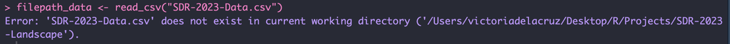

You probably got an error saying that the data doesn’t exist, but we know that it does. It’s because we didn’t write in the proper file path name.

How do you get the file path name?

- For Mac users, you can read this [article](https://support.apple.com/guide/mac-help/get-file-folder-and-disk-information-on-mac-mchlp1774/mac#:~:text=On%20your%20Mac%2C%20click%20the,bottom%20of%20the%20Finder%20window.) under *Show the path to a file or folder*.
- For Windows users, you can read this [article](https://www.wikihow.com/Find-a-File%27s-Path-on-Windows)

Let’s try to read in our data with the proper file path name:

```r
# filepath_data <- read_csv("/Users/victoriadelacruz/Desktop/R/Projects/SDR-2023-Landscape/data/SDR-2023-Data.csv")
```

Note: your computer user name will most likely show up in the file path name along with the different folders your R project and data are in (no one will have the same exact file path name)

Success!

### Syntax Errors

Syntax errors occur when you have missing or unmatched parentheses, curly braces, square brackets, or quotes. Try to run this code with a missing parenthesis: `library(tidyverse`

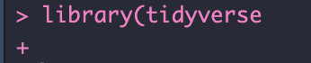

### Typos

Although typos may not seem like a big deal, they definitely are in code! Let’s attempt to print the filepath_data variable we made earlier:`print(filepath_dat)`

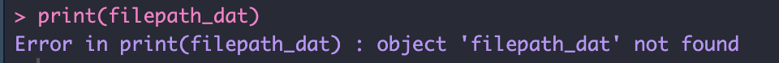

As you can see, the error message we got says that ‘filepath_dat’ was not found - this is because we have a typo. These can be tricky to find as it doesn’t explicitly tell us that it was a spelling error. Let’s correct our typo:

```r
# print(filepath_data)
```

Looks great!

### Solutions and Resources

There are going to be different types of errors you might encounter that was not covered in this troubleshooting guide. Here are some tips to help you resolve them:

1. Google Search

Google will be your best friend when it comes to solving errors! You can copy and paste your error into a Google search, and it will show you a bunch of resources and solutions others have done (chances are, someone else has run into the same or similar error).

2. ChatGPT

You can do the same with ChatGPT - copy and paste your error and it will lead you to some possible solutions. You may have to play around with what ChatGPT provides (for example, making sure your variable names are correct) to ensure you’re running the code you intended to.

3. Help Page

R has useful help pages for almost all packages and functions. For easy access to the help page, you can type `?function_name()` or `?package_name`. Let’s try this out with the ggplot() function:

```r
?ggplot() # type in the function or package name after the question mark
```

This code should have opened up the help page on the side. This contains what arguments the function takes in as well as some examples you could run to better understand how it works.

4. Resources

After doing a Google search, you’ll get a bunch of resources that you can look to. Here are some recommendations: - [W3 Schools](https://www.w3schools.com/r/default.asp) - [Geeks for Geeks](https://www.geeksforgeeks.org/r-tutorial/?ref=outind) - [Stack Overflow](https://stackoverflow.com/questions/tagged/r) - [R Bloggers](https://www.r-bloggers.com/2015/12/how-to-learn-r-2/)